# Cross-Checks’ Report

Compiled on 09/06/2023, 10:57

*FDI catch data (Table A) available*

*MED & BS Landing table available*

*AER landing table available*

More GSAs available in data. Only the first one (GSA18) was used in the analysis

# 1 Comparing total landings in weight between MEDBS and FDI EU Data Calls

Both MED & BS Landing table and FDI Table A Catch were analysed to report the mutual consistency of the total landings in weight.

## 1.1 GSA18

### 1.1.1 HKE

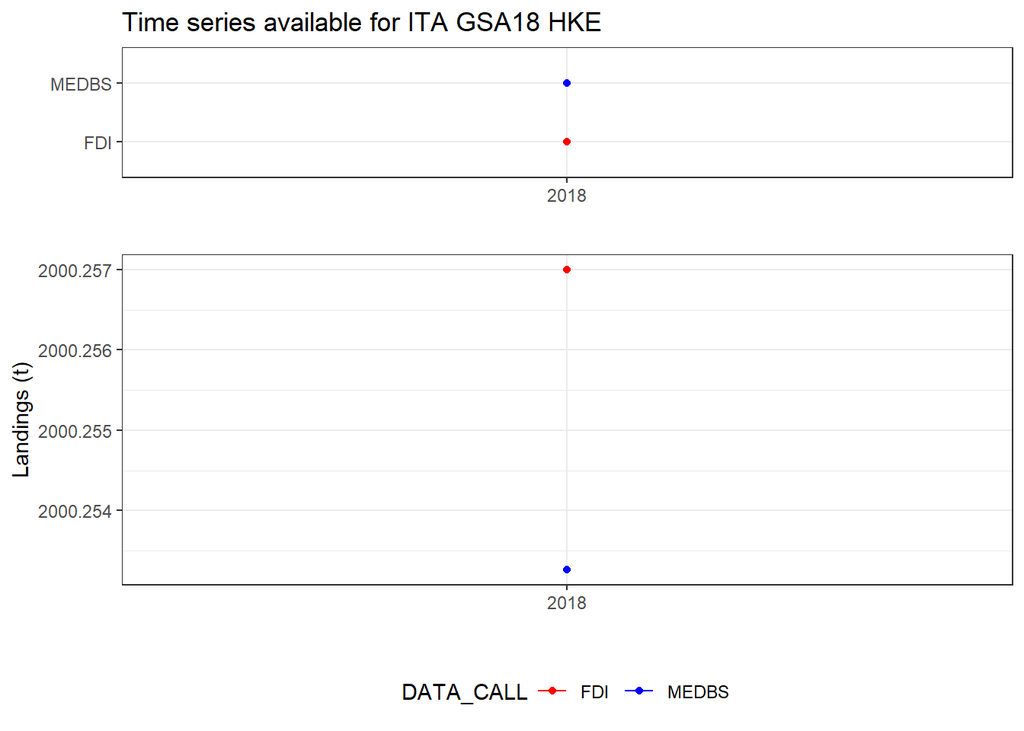

Plot of total landings in weight HKE - ITA - GSA18

*Summary table of total landings in weights.*

| YEAR | COUNTRY | GSA | SPECIES | LANDINGS | DATA_CALL |
| --- | --- | --- | --- | --- | --- |
| 2018 | ITA | GSA18 | HKE | 2000.253 | MEDBS |
| 2018 | ITA | GSA18 | HKE | 2000.257 | FDI |

# 2 Comparing total landings in weight between MEDBS, FDI and AER EU Data Calls

MED & BS Landing table, FDI Table A Catch and AER landings data were analysed to report the mutual consistency of the total landings in weight.

## 2.1 GSA18

### 2.1.1 HKE

[1] “Landings comparison has been done.”

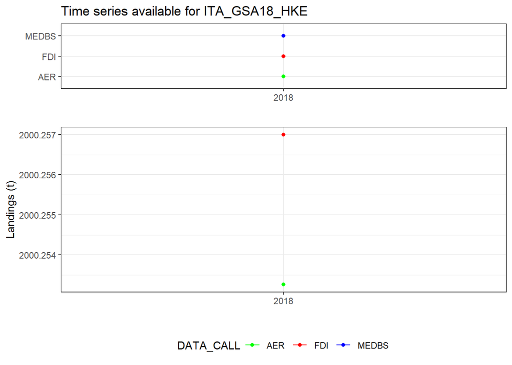

Plot of total landings in weight HKE - ITA - GSA18

*Summary table of total landings in weights.*

| YEAR | COUNTRY | GSA | SPECIES | LANDINGS | DATA_CALL |
| --- | --- | --- | --- | --- | --- |
| 2018 | ITA | GSA18 | HKE | 2000.253 | MEDBS |
| 2018 | ITA | GSA18 | HKE | 2000.257 | FDI |
| 2018 | ITA | GSA18 | HKE | 2000.253 | AER |

# 3 Comparing total landings in weight by gear between MEDBS and FDI EU Data Calls

Both MED & BS Landing table and FDI Table A Catch were analysed to report the mutual consistency of the total landings in weight.

## 3.1 GSA18

### 3.1.1 HKE

*Summary table of landings by gear in FDI and in MED & BS data call.*

| YEAR | COUNTRY | GSA | SPECIES | GEAR | LANDINGS | DATA_CALL |
| --- | --- | --- | --- | --- | --- | --- |
| 2018 | ITA | GSA18 | HKE | GNS | 15.40226 | MEDBS |
| 2018 | ITA | GSA18 | HKE | GTR | 0.23343 | MEDBS |
| 2018 | ITA | GSA18 | HKE | LLS | 334.74047 | MEDBS |
| 2018 | ITA | GSA18 | HKE | OTB | 1649.87710 | MEDBS |
| 2018 | ITA | GSA18 | HKE | GNS | 15.40400 | FDI |
| 2018 | ITA | GSA18 | HKE | GTR | 0.23400 | FDI |
| 2018 | ITA | GSA18 | HKE | LLS | 334.74100 | FDI |
| 2018 | ITA | GSA18 | HKE | OTB | 1649.87800 | FDI |

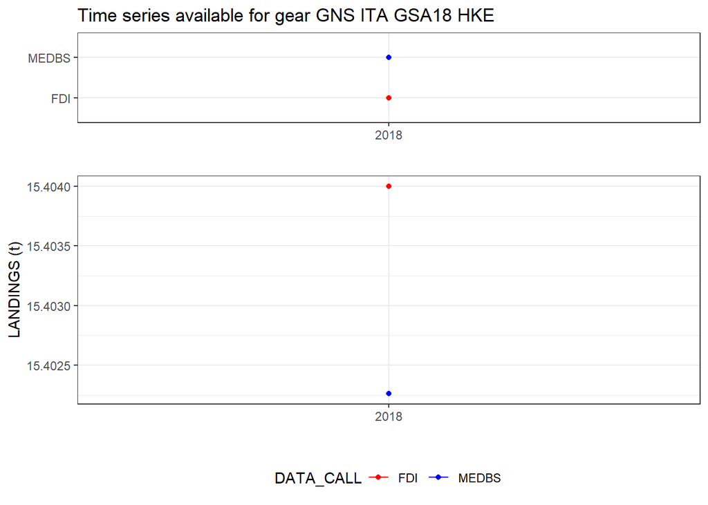

Plot of total landings in weight (GNS) - HKE - ITA - GSA18

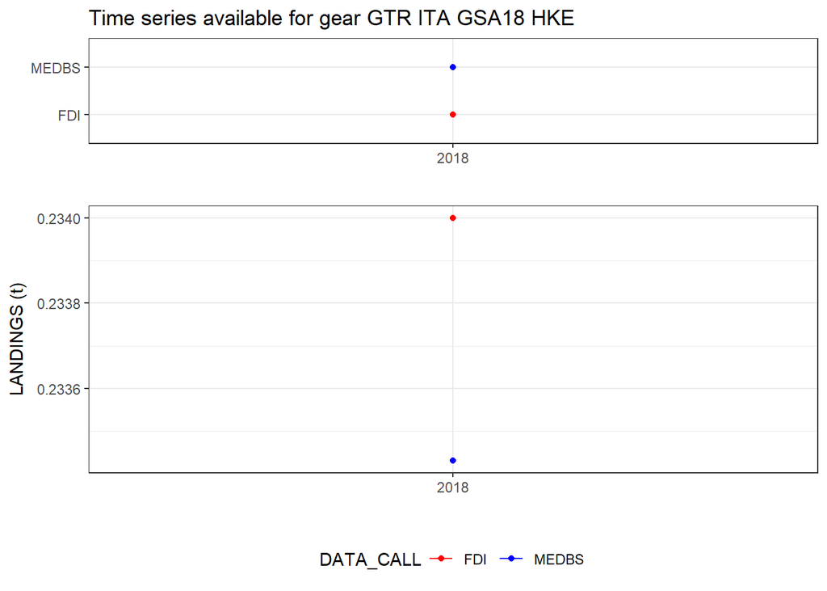

Plot of total landings in weight (GTR) - HKE - ITA - GSA18

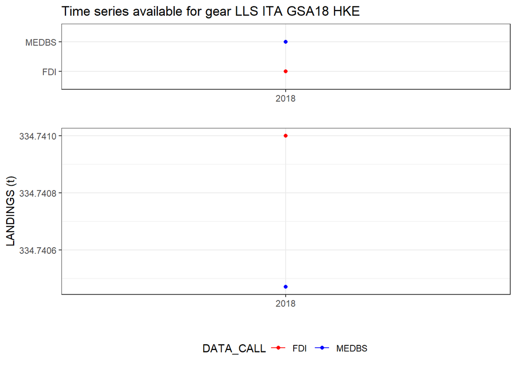

Plot of total landings in weight (LLS) - HKE - ITA - GSA18

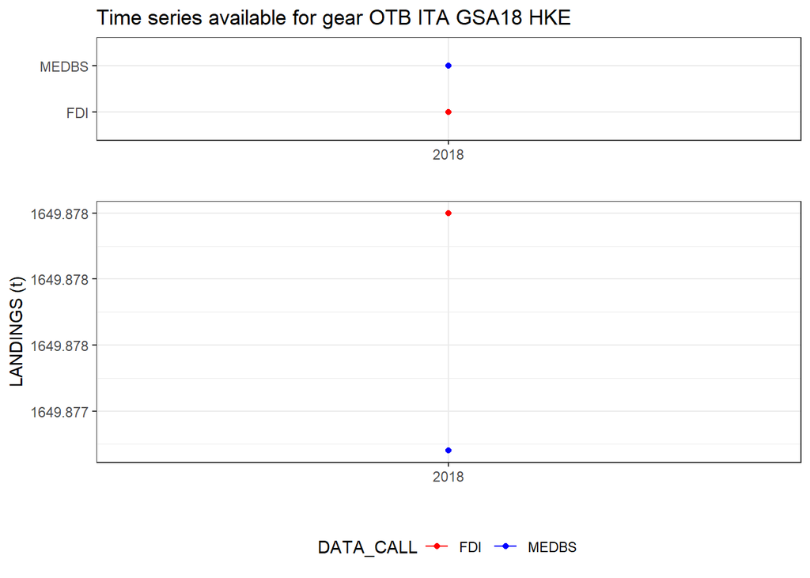

Plot of total landings in weight (OTB) - HKE - ITA - GSA18

# 4 Comparing total landings in weight by gear and quarter between MEDBS and FDI EU Data Calls

Both MED & BS Landing table and FDI Table A Catch were analysed to report the mutual consistency of the total landings in weight.

## 4.1 GSA18

### 4.1.1 HKE

*Summary table of landings by gear and quarter in FDI and in MED & BS data call.*

| YEAR | COUNTRY | GSA | SPECIES | GEAR | QUARTER | LANDINGS | DATA_CALL |
| --- | --- | --- | --- | --- | --- | --- | --- |
| 2018 | ITA | GSA18 | HKE | GNS | 1 | 5.49959 | MEDBS |
| 2018 | ITA | GSA18 | HKE | GNS | 2 | 3.34118 | MEDBS |
| 2018 | ITA | GSA18 | HKE | GNS | 3 | 4.19999 | MEDBS |
| 2018 | ITA | GSA18 | HKE | GNS | 4 | 2.36150 | MEDBS |
| 2018 | ITA | GSA18 | HKE | GTR | 1 | 0.05675 | MEDBS |
| 2018 | ITA | GSA18 | HKE | GTR | 2 | 0.10993 | MEDBS |
| 2018 | ITA | GSA18 | HKE | GTR | 3 | 0.03000 | MEDBS |
| 2018 | ITA | GSA18 | HKE | GTR | 4 | 0.03675 | MEDBS |
| 2018 | ITA | GSA18 | HKE | LLS | 1 | 31.25594 | MEDBS |
| 2018 | ITA | GSA18 | HKE | LLS | 2 | 100.19417 | MEDBS |
| 2018 | ITA | GSA18 | HKE | LLS | 3 | 104.02274 | MEDBS |
| 2018 | ITA | GSA18 | HKE | LLS | 4 | 99.26762 | MEDBS |
| 2018 | ITA | GSA18 | HKE | OTB | 1 | 411.84801 | MEDBS |
| 2018 | ITA | GSA18 | HKE | OTB | 2 | 462.42132 | MEDBS |
| 2018 | ITA | GSA18 | HKE | OTB | 3 | 240.17802 | MEDBS |
| 2018 | ITA | GSA18 | HKE | OTB | 4 | 535.42975 | MEDBS |
| 2018 | ITA | GSA18 | HKE | GNS | 1 | 5.50000 | FDI |
| 2018 | ITA | GSA18 | HKE | GNS | 2 | 3.34200 | FDI |
| 2018 | ITA | GSA18 | HKE | GNS | 3 | 4.20000 | FDI |
| 2018 | ITA | GSA18 | HKE | GNS | 4 | 2.36200 | FDI |
| 2018 | ITA | GSA18 | HKE | GTR | 1 | 0.05700 | FDI |
| 2018 | ITA | GSA18 | HKE | GTR | 2 | 0.11000 | FDI |
| 2018 | ITA | GSA18 | HKE | GTR | 3 | 0.03000 | FDI |
| 2018 | ITA | GSA18 | HKE | GTR | 4 | 0.03700 | FDI |
| 2018 | ITA | GSA18 | HKE | LLS | 1 | 31.25600 | FDI |
| 2018 | ITA | GSA18 | HKE | LLS | 2 | 100.19400 | FDI |
| 2018 | ITA | GSA18 | HKE | LLS | 3 | 104.02300 | FDI |
| 2018 | ITA | GSA18 | HKE | LLS | 4 | 99.26800 | FDI |
| 2018 | ITA | GSA18 | HKE | OTB | 1 | 411.84800 | FDI |
| 2018 | ITA | GSA18 | HKE | OTB | 2 | 462.42300 | FDI |
| 2018 | ITA | GSA18 | HKE | OTB | 3 | 240.17800 | FDI |
| 2018 | ITA | GSA18 | HKE | OTB | 4 | 535.42900 | FDI |

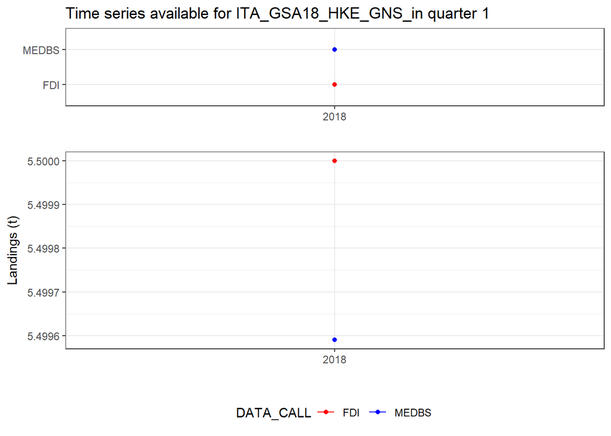

Plot of total landings in weight (GNS, quarter 1) - HKE - ITA - GSA18

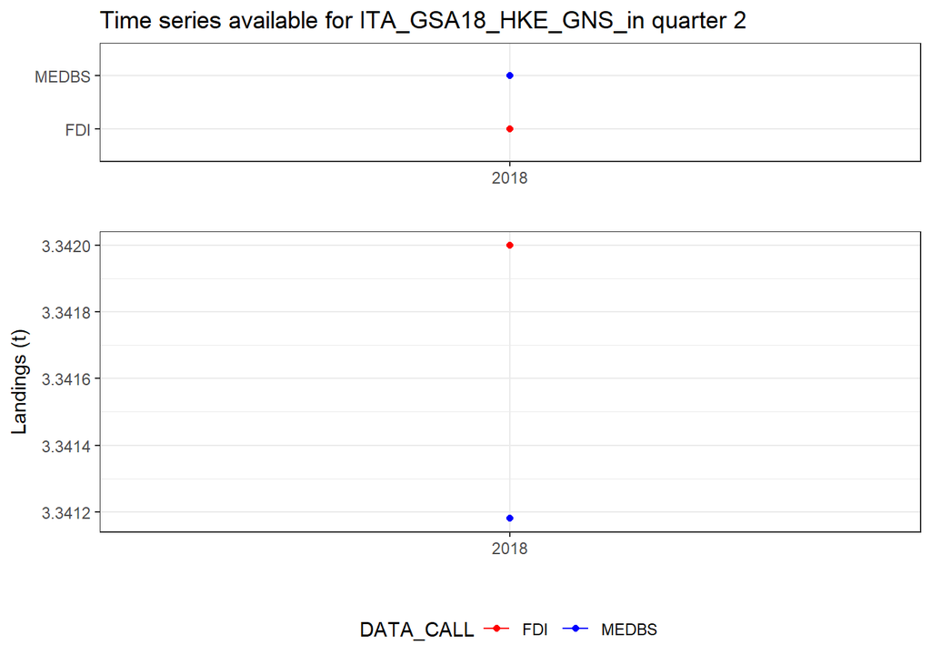

Plot of total landings in weight (GNS, quarter 2) - HKE - ITA - GSA18

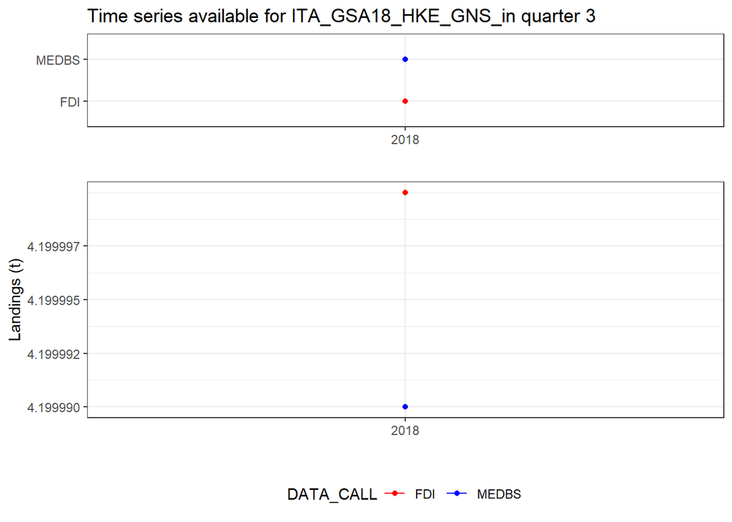

Plot of total landings in weight (GNS, quarter 3) - HKE - ITA - GSA18

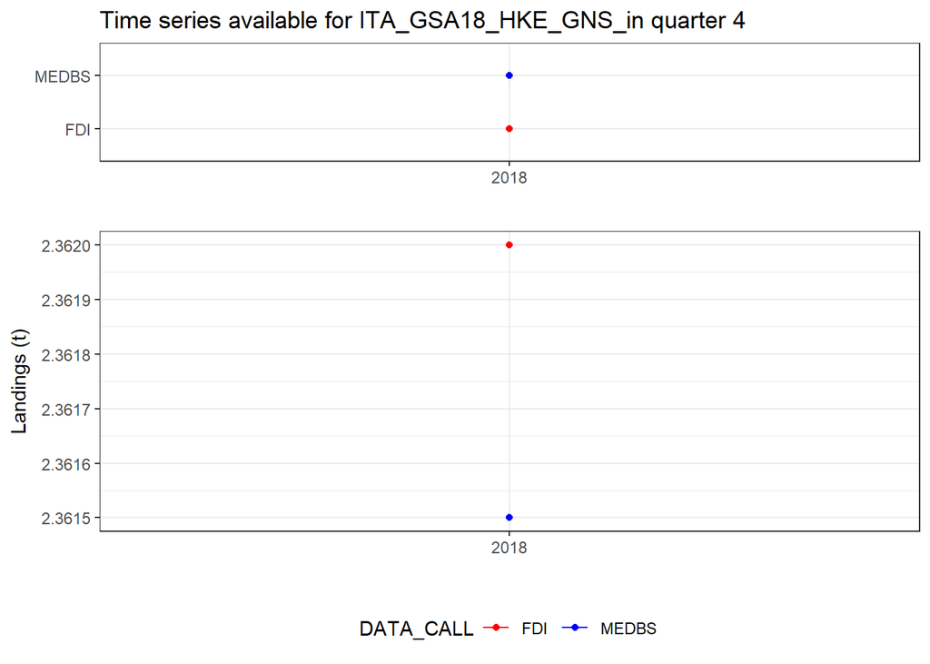

Plot of total landings in weight (GNS, quarter 4) - HKE - ITA - GSA18

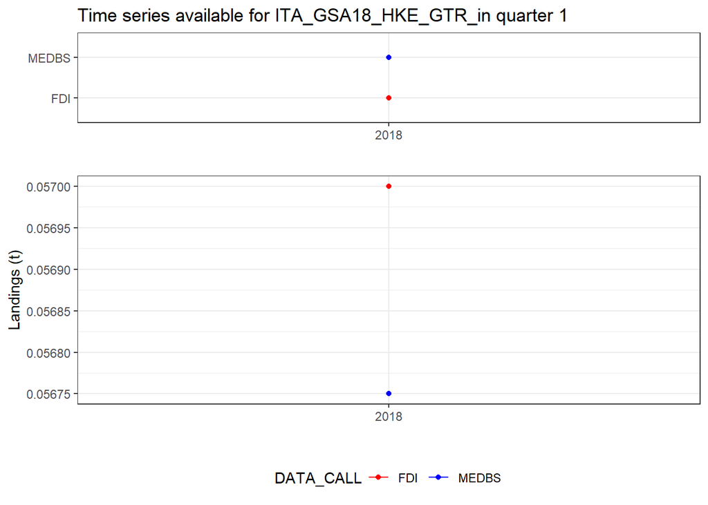

Plot of total landings in weight (GTR, quarter 1) - HKE - ITA - GSA18

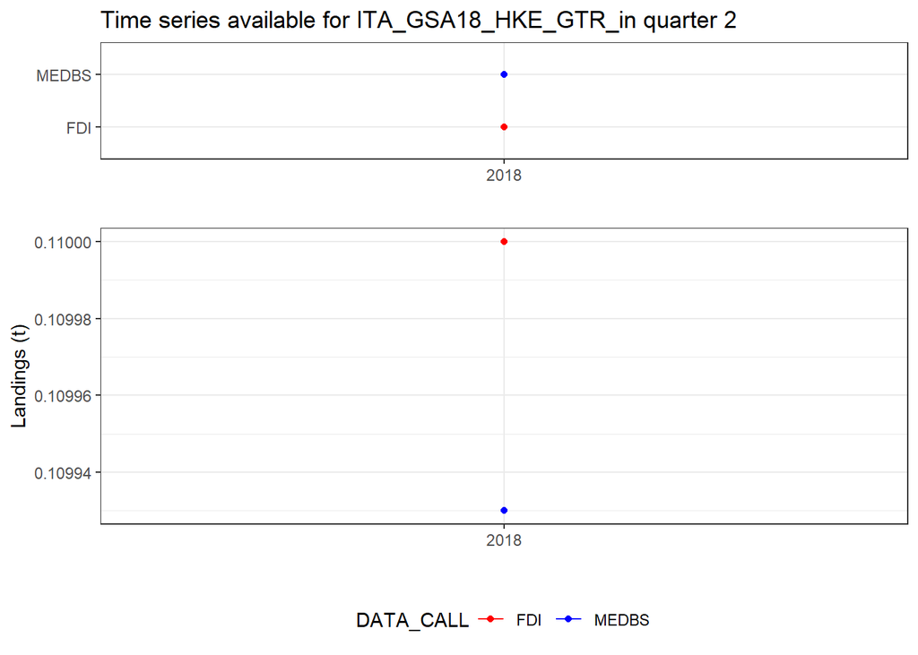

Plot of total landings in weight (GTR, quarter 2) - HKE - ITA - GSA18

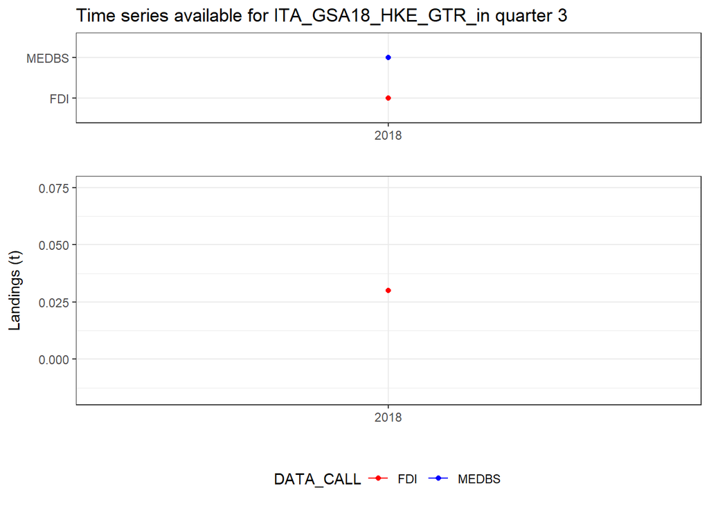

Plot of total landings in weight (GTR, quarter 3) - HKE - ITA - GSA18

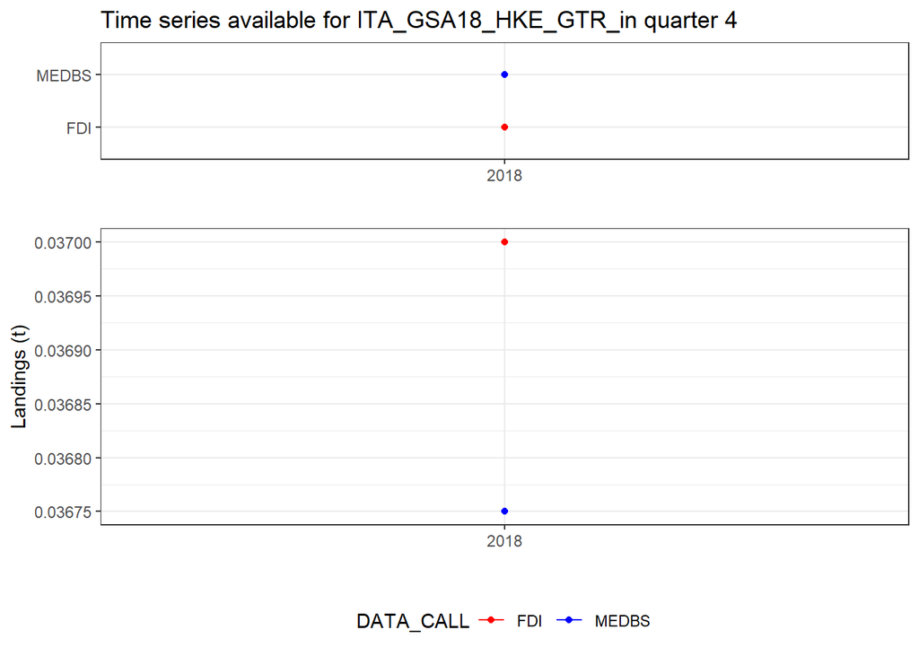

Plot of total landings in weight (GTR, quarter 4) - HKE - ITA - GSA18

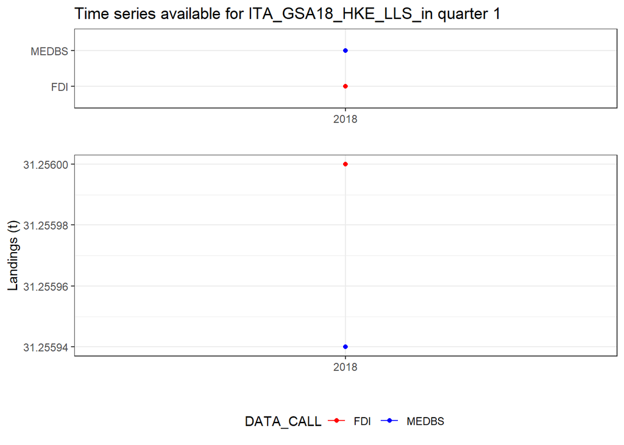

Plot of total landings in weight (LLS, quarter 1) - HKE - ITA - GSA18

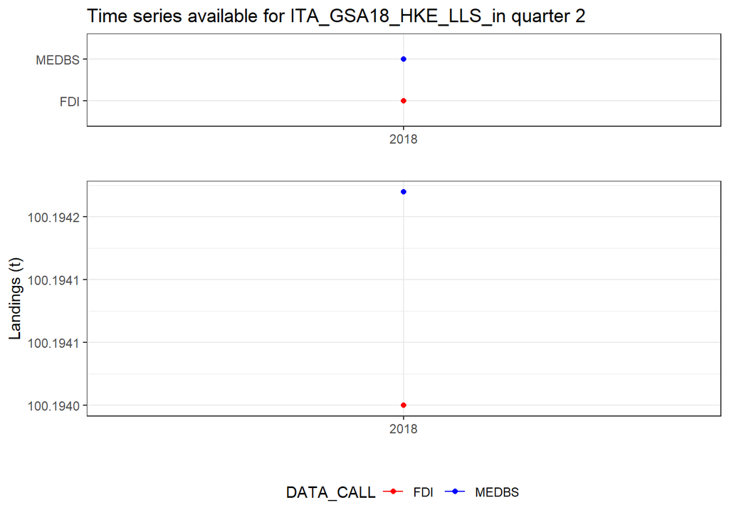

Plot of total landings in weight (LLS, quarter 2) - HKE - ITA - GSA18

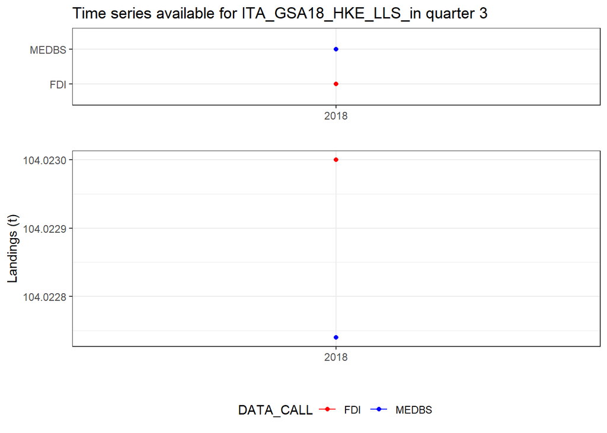

Plot of total landings in weight (LLS, quarter 3) - HKE - ITA - GSA18

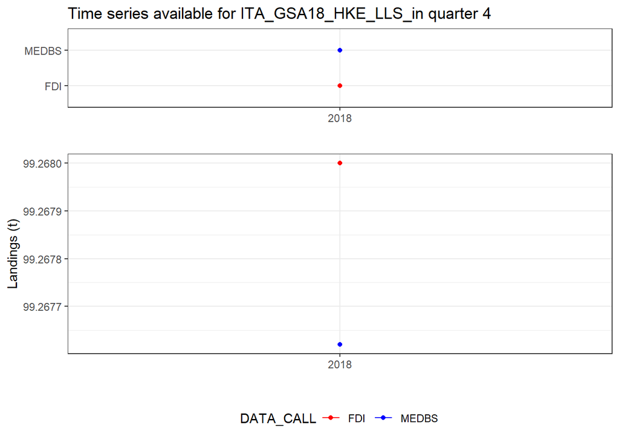

Plot of total landings in weight (LLS, quarter 4) - HKE - ITA - GSA18

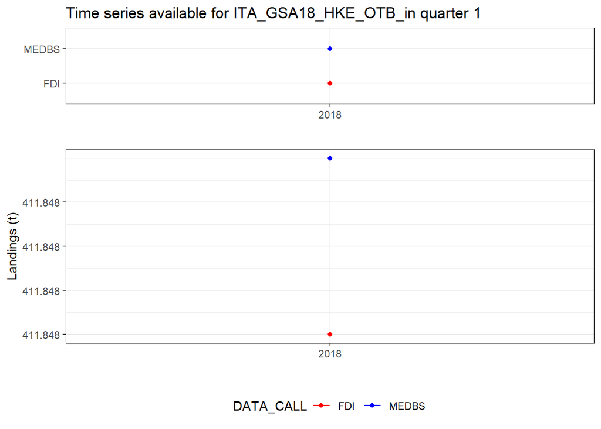

Plot of total landings in weight (OTB, quarter 1) - HKE - ITA - GSA18

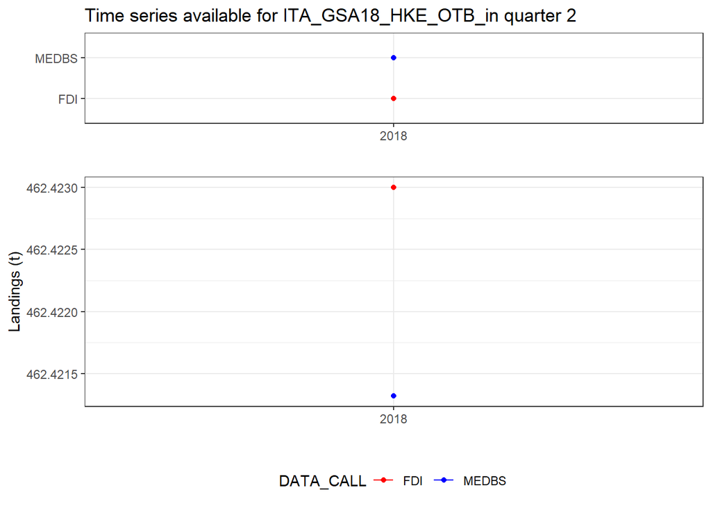

Plot of total landings in weight (OTB, quarter 2) - HKE - ITA - GSA18

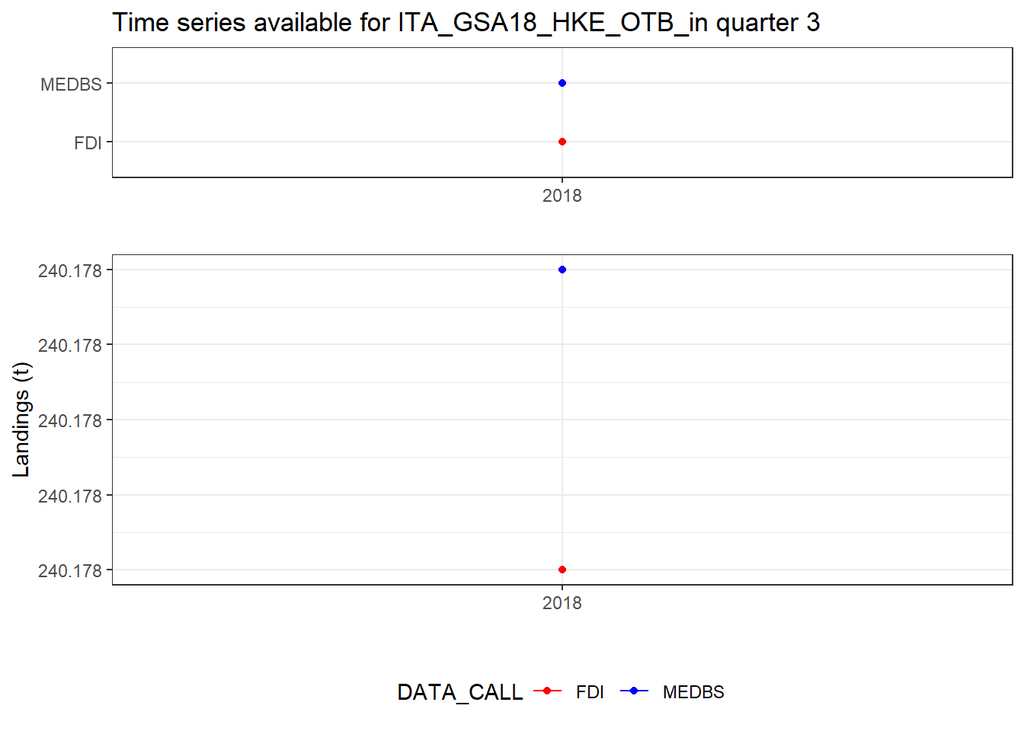

Plot of total landings in weight (OTB, quarter 3) - HKE - ITA - GSA18

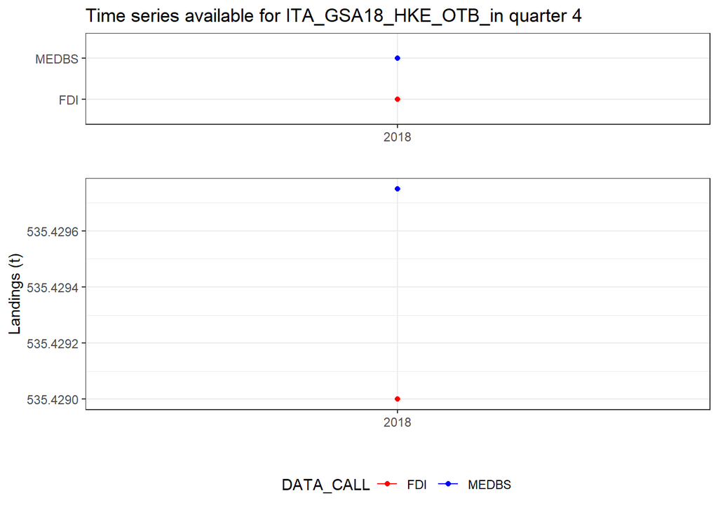

Plot of total landings in weight (OTB, quarter 4) - HKE - ITA - GSA18

# 5 Comparing total landings in weight by metier between MEDBS and FDI EU Data Calls

Both MED & BS Landing table and FDI Table A Catch were analysed to report the mutual consistency of the total landings in weight.

## 5.1 GSA18

### 5.1.1 HKE

*Summary table of total landings by metier in FDI and in MED & BS data call.*

| YEAR | COUNTRY | GSA | SPECIES | GEAR | FISHERY | MESH | METIER | LANDINGS | DATA_CALL |
| --- | --- | --- | --- | --- | --- | --- | --- | --- | --- |
| 2018 | ITA | GSA18 | HKE | GNS | DES | 16D20 | GNS_DES_16D20 | 15.35459 | MEDBS |
| 2018 | ITA | GSA18 | HKE | GNS | SLP | 16D20 | GNS_SLP_16D20 | 0.04767 | MEDBS |
| 2018 | ITA | GSA18 | HKE | GTR | DES | 16D20 | GTR_DES_16D20 | 0.23343 | MEDBS |
| 2018 | ITA | GSA18 | HKE | LLS | DES | NA | LLS_DES_NA | 334.74047 | MEDBS |
| 2018 | ITA | GSA18 | HKE | OTB | DES | 50D100 | OTB_DES_50D100 | 1539.96443 | MEDBS |
| 2018 | ITA | GSA18 | HKE | OTB | DWS | 50D100 | OTB_DWS_50D100 | 12.50995 | MEDBS |
| 2018 | ITA | GSA18 | HKE | OTB | MDD | 50D100 | OTB_MDD_50D100 | 97.40272 | MEDBS |
| 2018 | ITA | GSA18 | HKE | GNS | DES | 16D20 | GNS_DES_16D20 | 15.35600 | FDI |
| 2018 | ITA | GSA18 | HKE | GNS | SLP | 16D20 | GNS_SLP_16D20 | 0.04800 | FDI |
| 2018 | ITA | GSA18 | HKE | GTR | DES | 16D20 | GTR_DES_16D20 | 0.23400 | FDI |
| 2018 | ITA | GSA18 | HKE | LLS | DES | NA | LLS_DES_NA | 334.74100 | FDI |
| 2018 | ITA | GSA18 | HKE | OTB | DES | 40D50 | OTB_DES_40D50 | 1539.96400 | FDI |
| 2018 | ITA | GSA18 | HKE | OTB | DWS | 40D50 | OTB_DWS_40D50 | 12.51000 | FDI |
| 2018 | ITA | GSA18 | HKE | OTB | MDD | 40D50 | OTB_MDD_40D50 | 97.40400 | FDI |

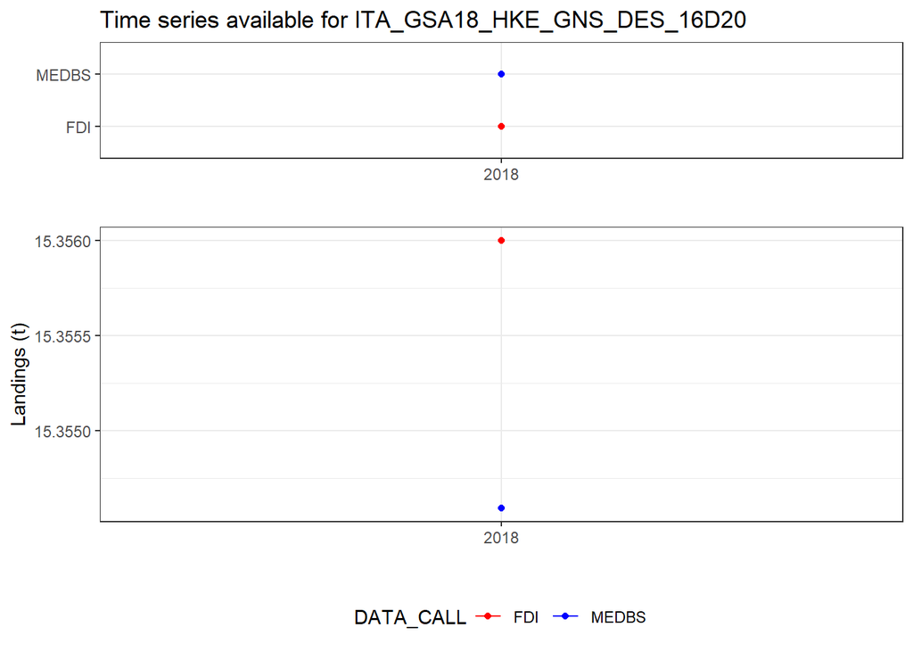

Plot of total landings in weight (metier: GNS_DES_16D20) - HKE - ITA - GSA18

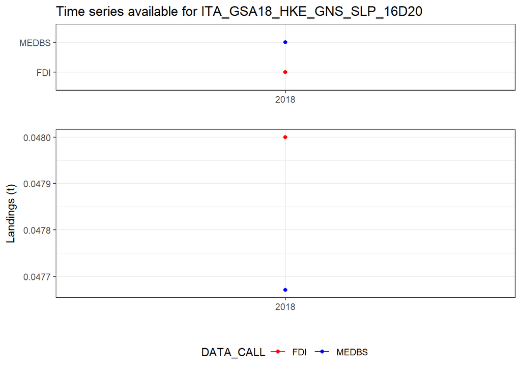

Plot of total landings in weight (metier: GNS_SLP_16D20) - HKE - ITA - GSA18

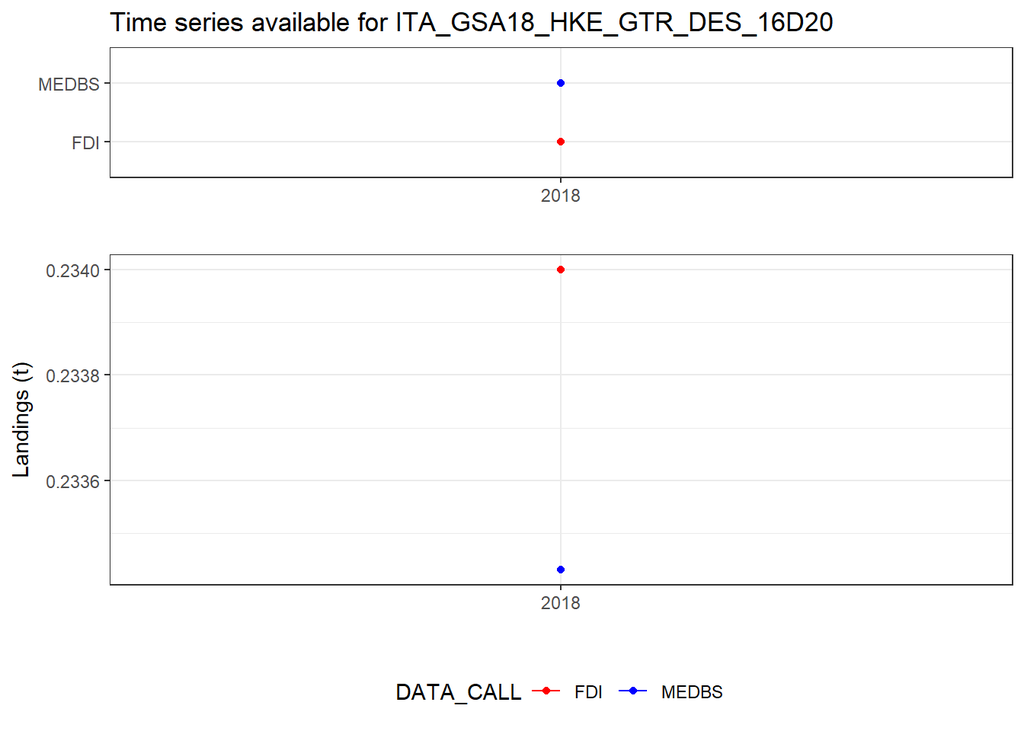

Plot of total landings in weight (metier: GTR_DES_16D20) - HKE - ITA - GSA18

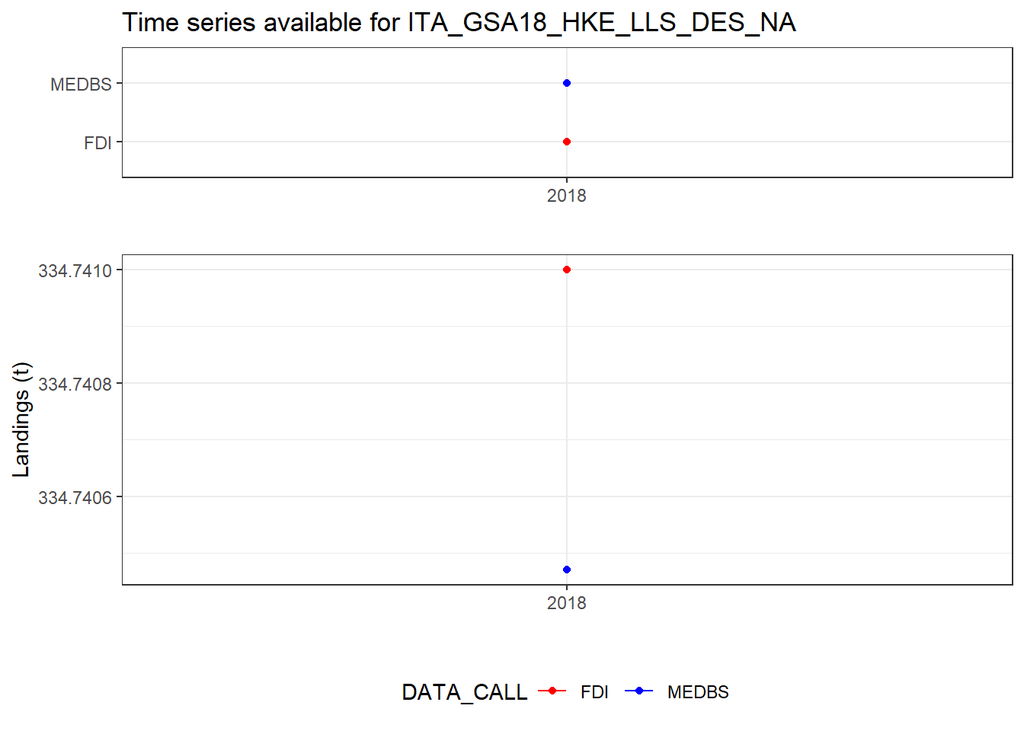

Plot of total landings in weight (metier: LLS_DES_NA) - HKE - ITA - GSA18

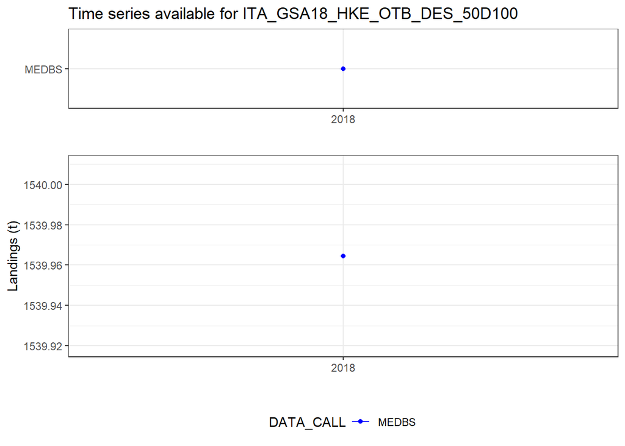

Plot of total landings in weight (metier: OTB_DES_50D100) - HKE - ITA - GSA18

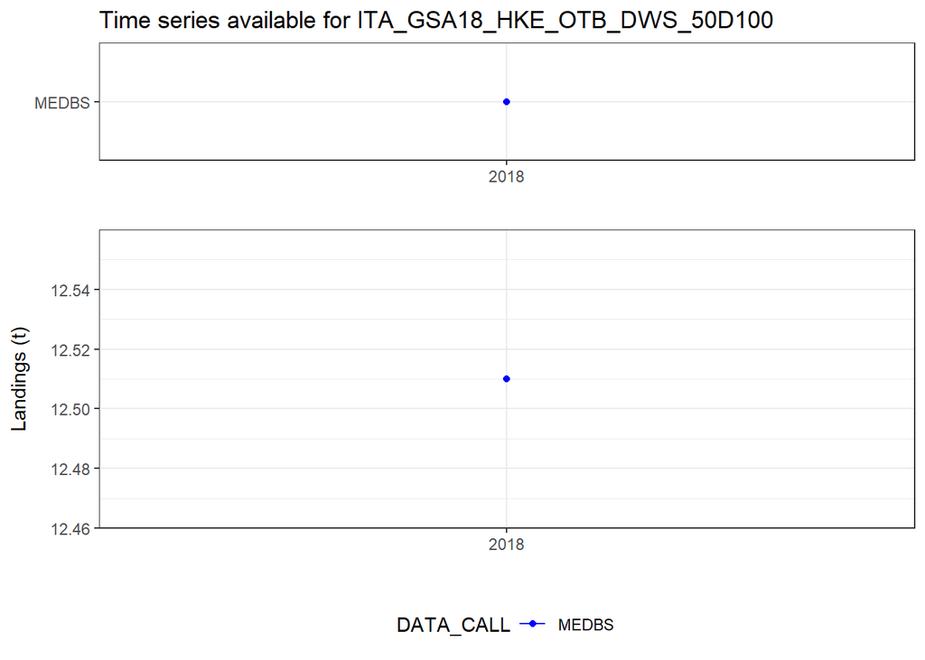

Plot of total landings in weight (metier: OTB_DWS_50D100) - HKE - ITA - GSA18

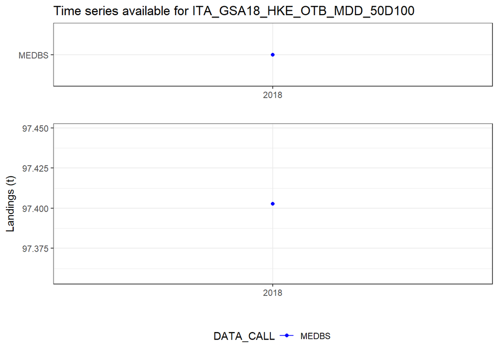

Plot of total landings in weight (metier: OTB_MDD_50D100) - HKE - ITA - GSA18

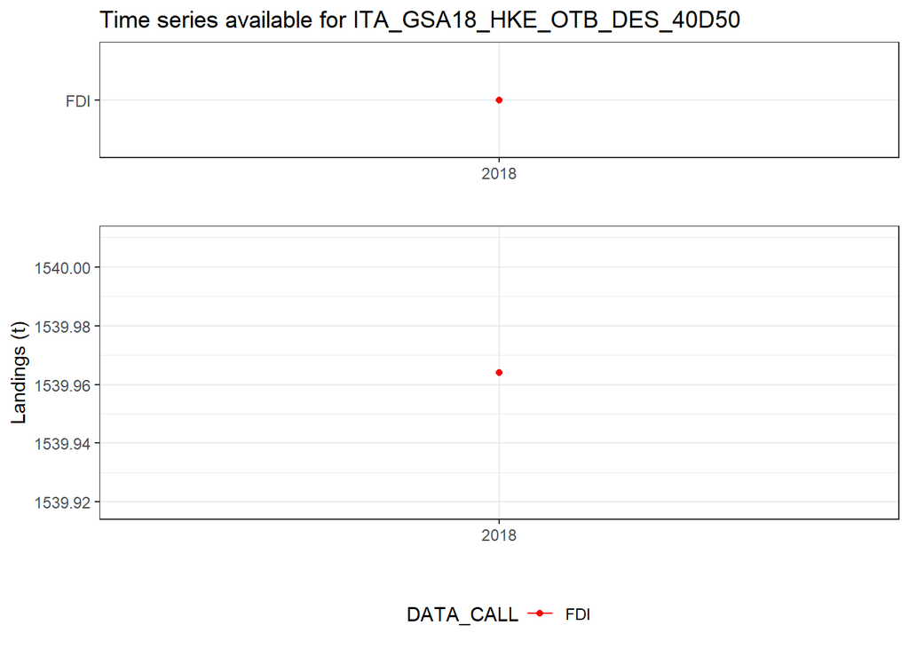

Plot of total landings in weight (metier: OTB_DES_40D50) - HKE - ITA - GSA18

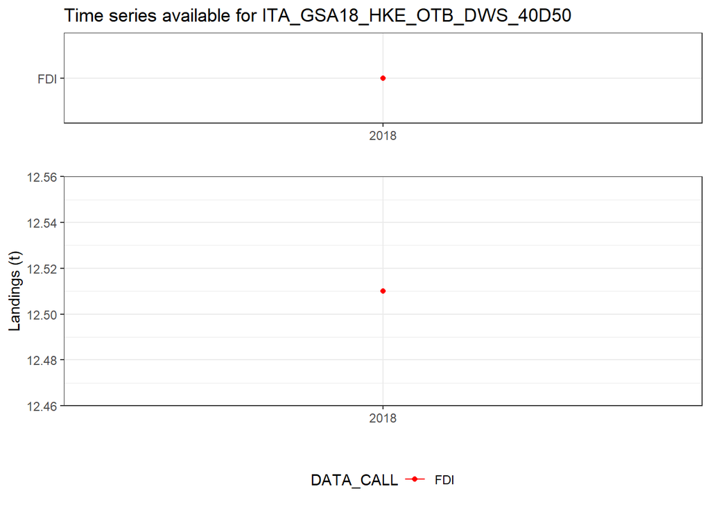

Plot of total landings in weight (metier: OTB_DWS_40D50) - HKE - ITA - GSA18

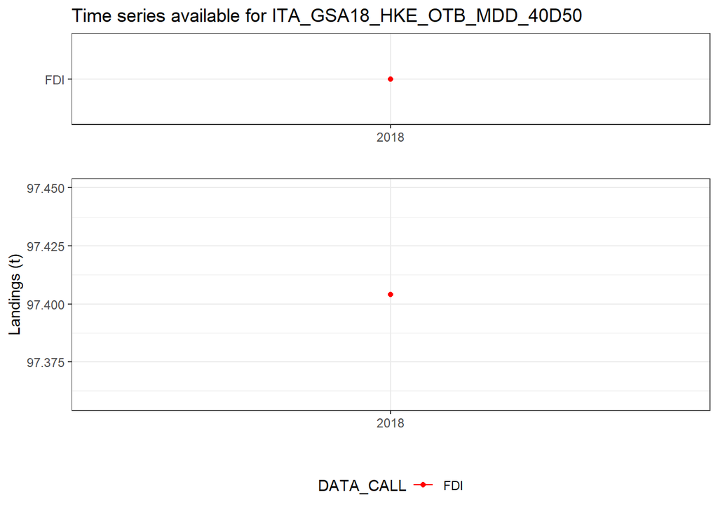

Plot of total landings in weight (metier: OTB_MDD_40D50) - HKE - ITA - GSA18